# nba three pointer precentage and winning precentage

Yiming Fan

Is there a correlation betwween 3-point shots ability and winning precentage?

## Overview

Since I was a child, I have watched the NBA. Nowadys, the basketball league is in the middle of a revolution that more and more teams are willing to take 3-point shots. In my project, I try to explore if taking 3-point shots can really maximize offensive efficiency by improving each team’s winning precentage. In other words, I want to know if there is a correlation between 3-point shots ability and winning precentage.

## Data dictionary

- **season**: a numeric variable describing which year of stats we are using.
- **team_name**:a catagorical variable describing each team’s name. options from: Houston Brooklyn Cleveland Toronto Dallas Boston Chicago Miami Denver Atlanta Golden State Oklahoma City New Orleans Orlando Utah Philadelphia Detroit LA Clippers LA Lakers Phoenix Portland Memphis Charlotte Washington Indiana San Antonio Milwaukee Sacramento Minnesota New York
- **number_of_3pointer_attempts**: a numeric variable describing 3 point shots attempted.
- **number_of_made**:a numeric variable describing successful 3 pointer attempts.
- **3pointer_percentage**:a numeric variable dividing made 3 pointer by total 3 pointer attempted.
- **winning_precentage**:a numeric variable dividing game won by total game played.

```r
nba <- read_csv("https://raw.githubusercontent.com/URstats/stat209-s18-fanyiming33/master/nba.csv")
nba
```

| season | team_name | number_of_threepointer_attempts | number_of_made | threepointer_precentage | winning_precentage |
| --- | --- | --- | --- | --- | --- |
| 2017 | Houston | 42.8 | 15.7 | 0.366 | 0.772 |
| 2017 | Brooklyn | 34.7 | 12.0 | 0.346 | 0.322 |
| 2017 | Cleveland | 32.9 | 12.2 | 0.370 | 0.607 |
| 2017 | Toronto | 32.4 | 11.6 | 0.357 | 0.719 |
| 2017 | Dallas | 32.4 | 11.7 | 0.361 | 0.310 |
| 2017 | Boston | 31.4 | 11.6 | 0.370 | 0.678 |
| 2017 | Chicago | 30.9 | 11.0 | 0.356 | 0.351 |
| 2017 | Miami | 30.7 | 11.0 | 0.359 | 0.517 |
| 2017 | Denver | 30.4 | 11.1 | 0.366 | 0.552 |
| 2017 | Atlanta | 30.0 | 11.0 | 0.366 | 0.305 |

[output cut: 140 more lines]

## Exploratory Analysis

| season | team_name | number_of_threepointer_attempts | number_of_made | threepointer_precentage | winning_precentage |
| --- | --- | --- | --- | --- | --- |
| 2017 | Houston | 42.8 | 15.7 | 0.366 | 0.772 |
| 2017 | Brooklyn | 34.7 | 12.0 | 0.346 | 0.322 |
| 2017 | Cleveland | 32.9 | 12.2 | 0.370 | 0.607 |
| 2017 | Toronto | 32.4 | 11.6 | 0.357 | 0.719 |
| 2017 | Dallas | 32.4 | 11.7 | 0.361 | 0.310 |
| 2017 | Boston | 31.4 | 11.6 | 0.370 | 0.678 |
| 2017 | Chicago | 30.9 | 11.0 | 0.356 | 0.351 |
| 2017 | Miami | 30.7 | 11.0 | 0.359 | 0.517 |
| 2017 | Denver | 30.4 | 11.1 | 0.366 | 0.552 |
| 2017 | Atlanta | 30.0 | 11.0 | 0.366 | 0.305 |

[output cut: 20 more lines]

[figure not shown]

[interactive chart not shown]

```r
rocket <- filter(nba, team_name == "Houston")
rocket
```

| season | team_name | number_of_threepointer_attempts | number_of_made | threepointer_precentage | winning_precentage |
| --- | --- | --- | --- | --- | --- |
| 2017 | Houston | 42.8 | 15.7 | 0.366 | 0.772 |
| 2016 | Houston | 40.3 | 14.4 | 0.357 | 0.671 |
| 2015 | Houston | 30.9 | 10.7 | 0.347 | 0.500 |
| 2014 | Houston | 32.7 | 11.4 | 0.348 | 0.683 |
| 2013 | Houston | 26.6 | 9.5 | 0.358 | 0.659 |

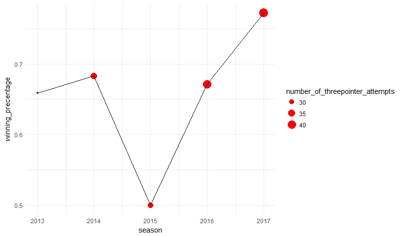

```r
ggplot(rocket, aes(season, winning_precentage)) +
  geom_point(aes(size=number_of_threepointer_attempts), color="red") +
  geom_line()
```

## References

“NBA Statistics and League Leaders.” NBA Stats, sports.espn.go.com/nba/statistics?season=2009&seasontype=2.